# State MSM Profile: **North Dakota**

### Background & Methods

In 2015-2016, researchers at Emory University partnered with colleagues at the Centers for Disease Control and Prevention (CDC) to develop methods to estimate the number of men who have sex with men (MSM) residing in each county in the United States. Using population and housing data from the [American Community Survey](https://www.census.gov/programs-surveys/acs/) and estimates from two peer-reviewed publications ([Oster et al., 2015](http://www.ncbi.nlm.nih.gov/pubmed/26115985) & [Purcell et al., 2012](http://www.ncbi.nlm.nih.gov/pubmed/23049658)), they derived an indirect estimate of MSM population sizes that took into account both the urbanicity of the county as well as its density of households with a male householder and a male same-sex partner.

The full methodology is published in the *Journal of Medical Internet Research - Public Health and Surveillance*:

> [Grey JA, Bernstein KT, Sullivan PS, Purcell DW, Chesson HW, Gift TL, Rosenberg ES. Estimating the population sizes of men who have sex with men in US states and counties using data from the American Community Survey. JMIR Public Health Surveill 2016;2(1):e14. DOI: 10.2196/publichealth.5365](http://publichealth.jmir.org/2016/1/e14/)

### Overview of MSM in North Dakota

An estimated **4,446** men who have sex with men (MSM) resided in North Dakota in 2013, representing 0.1% of the 4,503,084 MSM in the United States. Of the 270,992 adult men of North Dakota, 1.6% had had sex with another man in the past 5 years, which was less than the overall percentage of adult men in the United States who were MSM (3.9%).

Most MSM in North Dakota resided in counties within medium or small metropolitan areas (53.5%). No MSM in North Dakota resided in a large metropolitan area.

##### **Percentage of MSM by urbanicity, United States and North Dakota, 2013**

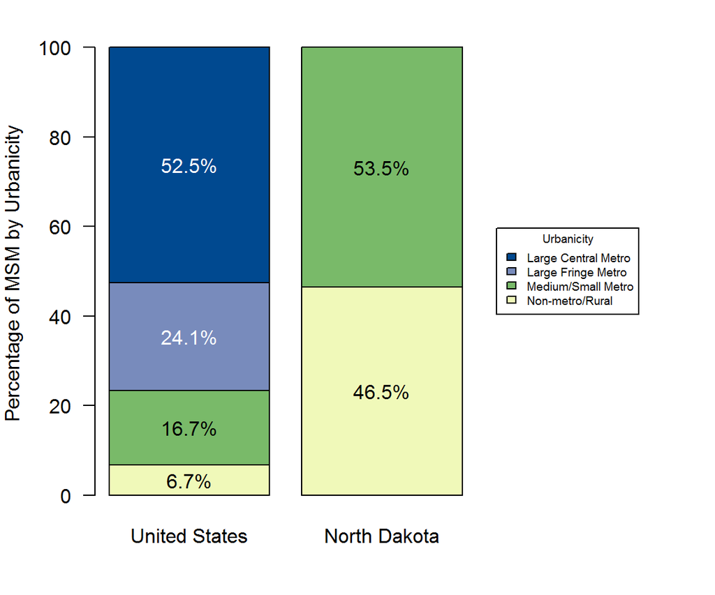

### MSM in North Dakota Counties

Among counties or county-equivalent areas in North Dakota, Cass County had the largest population of MSM at 1,120, representing 25.2% of all MSM in the state. Eddy County had the highest percentage of MSM among adult men in North Dakota at 8.3%. This was greater than the percentage for North Dakota as a whole, which was 1.6% of adult men.

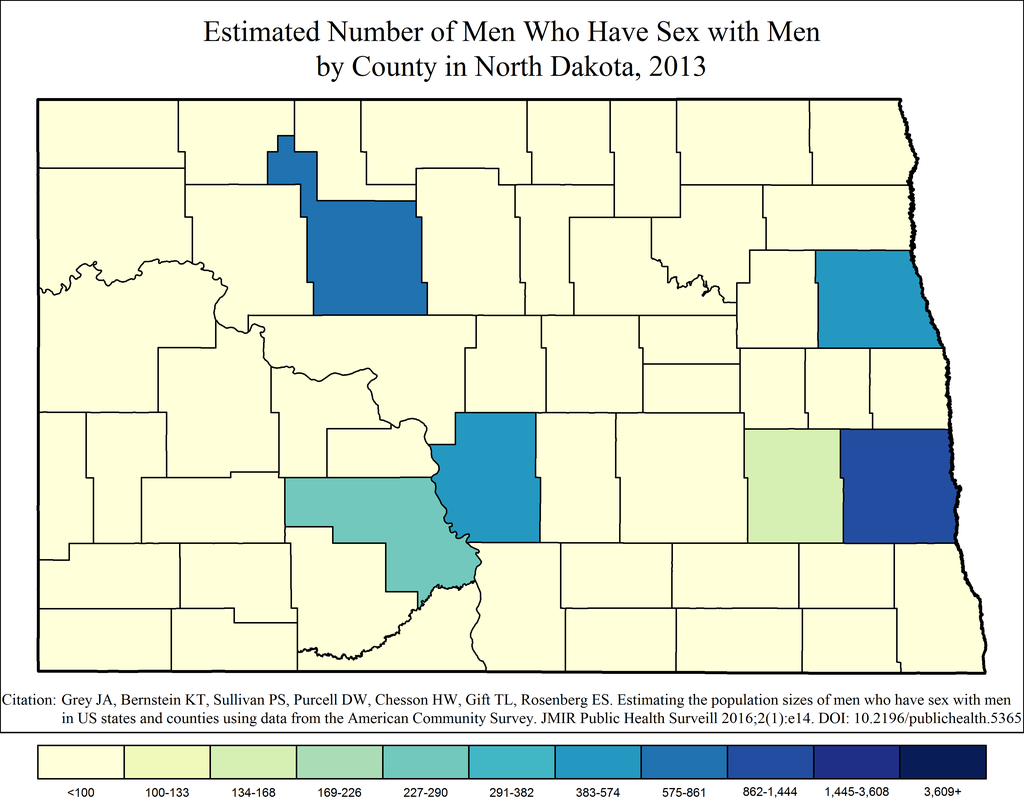

Note: Range cutpoints for the map are based on the distribution of MSM among all counties in the United States.

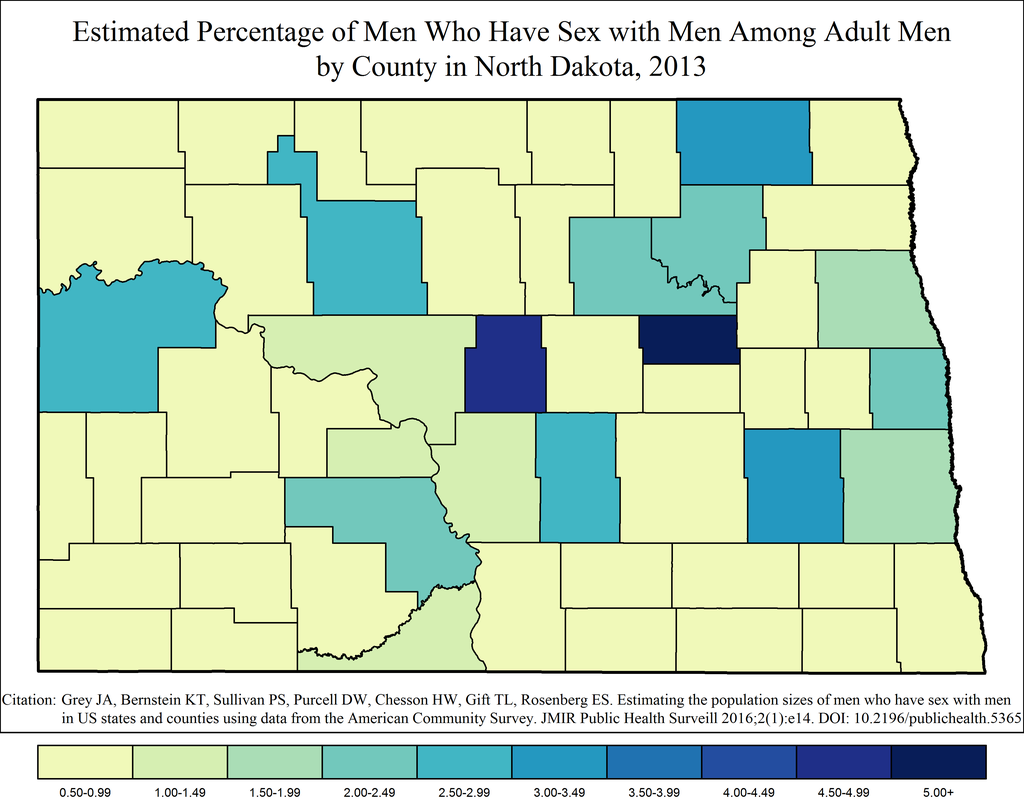

### MSM in North Dakota Metropolitan Statistical Areas

#### Fargo Metropolitan Statistical Area

The Fargo MSA overlaps two states: Minnesota and North Dakota. The North Dakota portion of the MSA had the largest metropolitan population of MSM in North Dakota at 1,120, or 25.2% of all MSM in the state and 70.2% of the 1,595 MSM in the MSA. Of the 60,653 adult men in the North Dakota part of Fargo, an estimated 1.8% were MSM. This was less than the percentage of MSM among adult men in the MSA as a whole, which was 1.9% of adult men (1,595 out of 82,978).

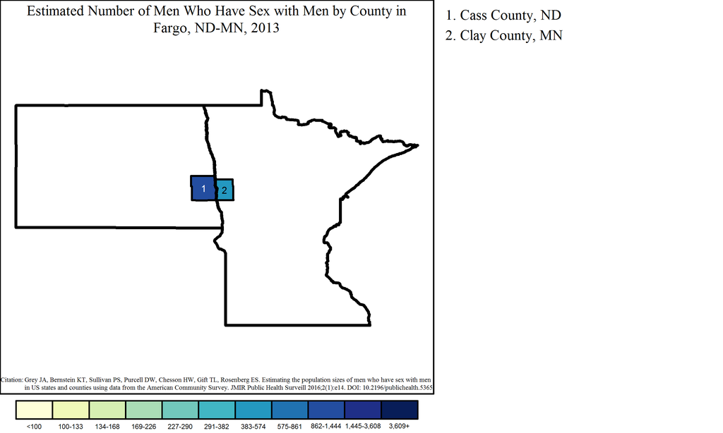

Note: Range cutpoints for the map are based on the distribution of MSM among all counties in the United States.

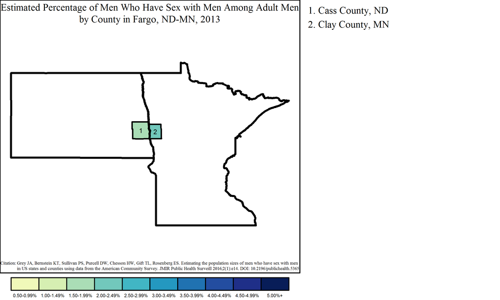

#### Bismarck Metropolitan Statistical Area

The Bismarck MSA had a population of 718 MSM, or 16.1% of all MSM in North Dakota. Of the 44,357 adult men in Bismarck, an estimated 1.6% were MSM.

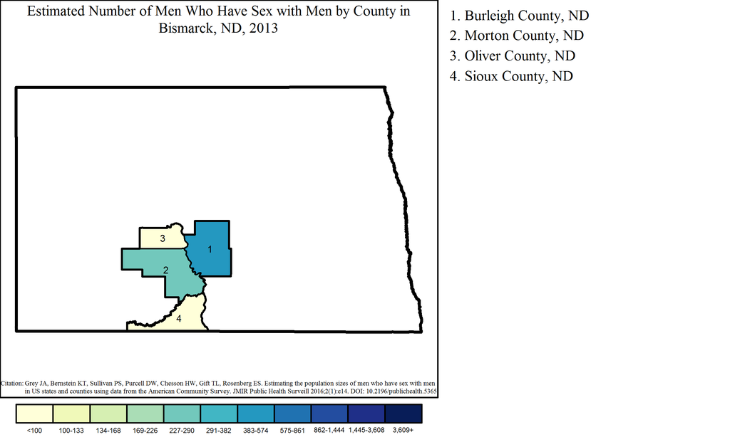

Note: Range cutpoints for the map are based on the distribution of MSM among all counties in the United States.

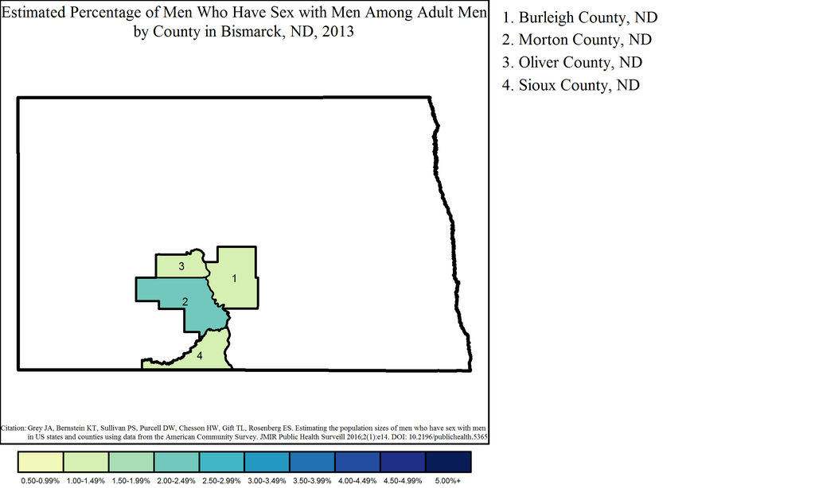

#### Grand Forks Metropolitan Statistical Area

The Grand Forks MSA overlaps two states: Minnesota and North Dakota. The North Dakota portion of the MSA had 542 MSM, or 12.2% of all MSM in the state and 77.4% of the 700 MSM in the MSA. Of 27,687 adult men in the North Dakota part of Grand Forks, 2.0% were MSM. This was greater than the overall percentage of MSM among adult men in the MSA, which was 1.8% of adult men (700 out of 39,794).

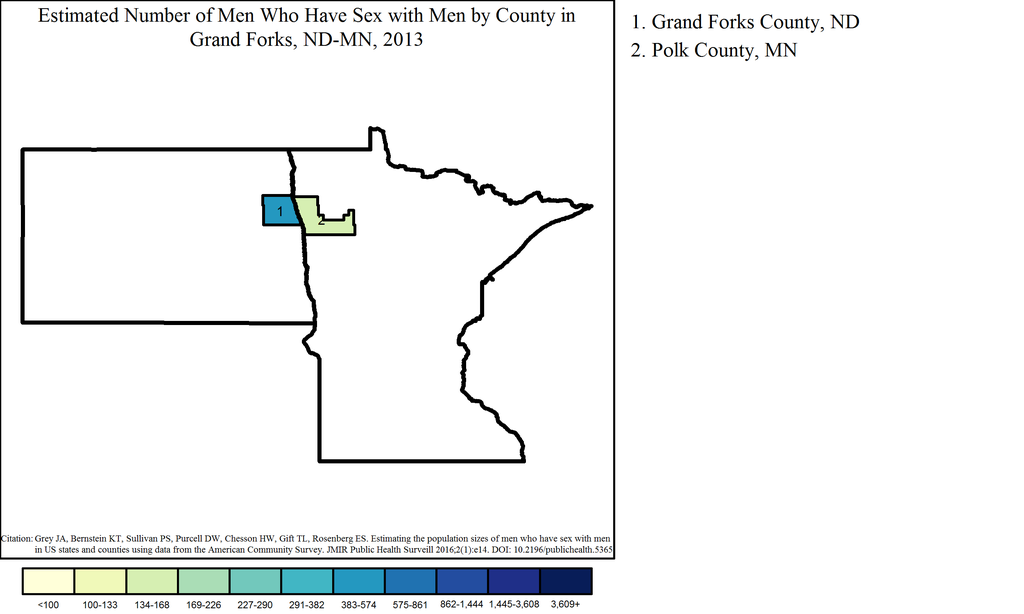

Note: Range cutpoints for the map are based on the distribution of MSM among all counties in the United States.

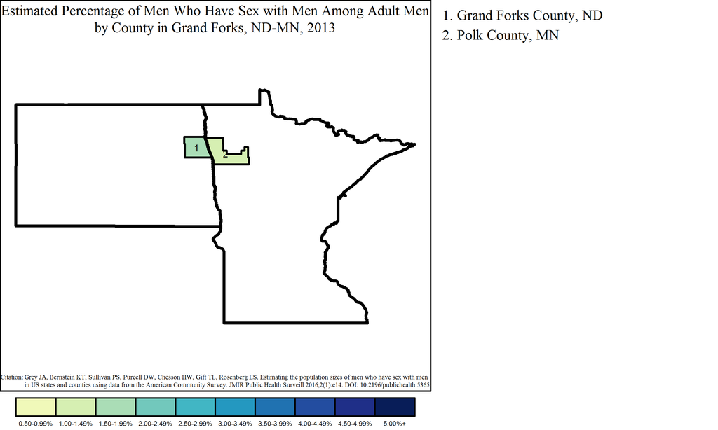